# IDS investigation worksheet

by Mean Girls: Alfie, Kate, Brook, Jonah & Lucio

2026-11-27

**Note:** You can use this file as you ‘working document’ where you can try out various investigation ideas and keep notes about your findings. How you use and structure this file is up to you. It is recommended that you keep notes about what you are investigating and what you find as this will make the process of creating your presentation and report easier. Please note that you *do not* need to submit this file as part of your group project.

```r
library(tidyverse)
library(tidymodels)
# Add any other libraries here
```

Question: What physical and orbital characteristics (such as absolute magnitude, estimated diameter, and velocity) are the strongest indicators of whether a near-Earth asteroid is classified as potentially hazardous?

Variables that might be related: - Miss distance - Size (diameter) - Velocity

https://www.kaggle.com/datasets/sunethjayawardana/nasa-near-earth-objects-neo-full-dataset

• Near-Earth Objects (NEOs): Any asteroid or comet that comes within 1.3 AU of the Sun. • Potentially Hazardous Asteroids (PHAs): A specific subset of NEOs that pose a more significant threat. To be classified as a PHA, the asteroid must: - Come within 0.05 AU of Earth (about 4.6 million miles or 7.5 million kilometers). - Be large enough to cause significant regional damage (typically larger than 140 meters or 460 feet in diameter).

```r
# load your data
nearest_earth_objects <- read_csv("data/nearest-earth-objects(1910-2024).csv")
neo_dur_df <- read_csv("data/neo_dur_df.csv")
```

```
## ──────────────────────────────────────────────────────── Delimiter: "," chr
## (8): equinox, orbit_class_type, orbit_class_description, name, orbitin... dbl
## (32): ...1, id, orbit_id, data_arc_in_days, observations_used, orbit_un... lgl
## (1): is_potentially_hazardous_asteroid dttm (1): orbit_determination_date date
## (2): first_observation_date, last_observation_date
```

```r
variable_reference <-  tribble(
  ~variable, ~category, ~description,
  # Identification and observation information
  "...1", "Identification", "Automatically generated row index; not an asteroid characteristic.",
  "id", "Identification", "Unique numerical identifier assigned to the asteroid.",
  "neo_reference_id", "Identification", "NASA reference identification number for the near-Earth object.",
  "name", "Identification", "Official name or designation of the asteroid.",
  "orbit_id", "Observation", "Identifier of the particular orbital solution associated with the asteroid.",
  "orbit_determination_date", "Observation", "Date and time when the asteroid's orbital solution was determined or updated.",
  "first_observation_date", "Observation", "Date of the earliest recorded observation of the asteroid.",
  "last_observation_date", "Observation", "Date of the most recent observation included in the orbital data.",
  "data_arc_in_days", "Observation", "Number of days between the first and last recorded observations.",
  "observations_used", "Observation", "Number of observations used to calculate the asteroid's orbit.",
  "orbit_uncertainty", "Observation", "Orbital uncertainty parameter (U); lower values generally indicate greater orbital certainty.",
  # Orbital characteristics
  "minimum_orbit_intersection", "Orbital characteristics", "Minimum Orbit Intersection Distance (MOID): minimum distance between the asteroid's orbital path and Earth's orbital path, usually in AU.",
  "jupiter_tisserand_invariant", "Orbital characteristics", "Dimensionless parameter used to classify small Solar System bodies and describe their orbital relationship with Jupiter.",
  "epoch_osculation", "Orbital characteristics", "Reference time, expressed as a Julian date, for the asteroid's osculating orbital elements.",
  "eccentricity", "Orbital characteristics", "Measures how elliptical the asteroid's orbit is. Zero represents a circular orbit; values approaching one represent increasingly elongated elliptical orbits.",
  "semi_major_axis", "Orbital characteristics", "Half the longest diameter of the asteroid's elliptical orbit, measured in AU.",
  "inclination", "Orbital characteristics", "Angle between the asteroid's orbital plane and the ecliptic.",
  "ascending_node_longitude", "Orbital characteristics", "Angle describing the orientation of the orbit at the point where it crosses the ecliptic from south to north.",
  "orbital_period", "Orbital characteristics", "Time required for the asteroid to complete one revolution around the Sun, measured in days.",
  "perihelion_distance", "Orbital characteristics", "Minimum distance between the asteroid and the Sun during its orbit, measured in AU.",
  "perihelion_argument", "Orbital characteristics", "Angle describing the orientation of the asteroid's perihelion within its orbital plane.",
  "aphelion_distance", "Orbital characteristics", "Maximum distance between the asteroid and the Sun during its orbit, measured in AU.",
  "perihelion_time", "Orbital characteristics", "Julian date corresponding to the time when the asteroid passes its closest point to the Sun.",
  "mean_anomaly", "Orbital characteristics", "Angular measurement describing the asteroid's position along its orbit relative to perihelion.",
  "mean_motion", "Orbital characteristics", "Average angular speed of the asteroid along its orbit, usually measured in degrees per day.",
  "equinox", "Orbital characteristics", "Reference coordinate system used to define the orbital elements; J2000 refers to the standard astronomical reference epoch.",
  "orbit_class_type", "Orbital classification", "Short code identifying the asteroid's orbital classification, e.g. whether they approach (Amor), cross outside (Apollo), cross inside (Atens), or do not cross (Atira) Earth's orbit",
  "orbit_class_description", "Orbital classification", "Written description of the asteroid's orbital classification.",
  # Physical characteristics and potential hazards
  "absolute_magnitude_h", "Physical characteristics", "Absolute magnitude (H), representing intrinsic brightness. Smaller values indicate brighter objects.",
  "estimated_diameter_kilometers_min", "Physical characteristics", "Lower estimate of the asteroid's diameter in kilometres.",
  "estimated_diameter_kilometers_max", "Physical characteristics", "Upper estimate of the asteroid's diameter in kilometres.",
  "is_potentially_hazardous_asteroid", "Hazard classification", "TRUE or FALSE indicator of whether NASA classifies the asteroid as potentially hazardous.",
  # Close approach information
  "orbiting_body0", "Close approach 1", "First recorded celestial body approached by the asteroid.",
  "miss_distance_kilometers0", "Close approach 1", "Distance to the first recorded celestial body at closest approach, in kilometres.",
  "relative_velocity0", "Close approach 1", "Velocity relative to the first recorded celestial body at closest approach, in km/s.",

  "orbiting_body1", "Close approach 2", "Second recorded celestial body approached by the asteroid.",
  "miss_distance_kilometers1", "Close approach 2", "Distance to the second recorded celestial body at closest approach, in kilometres.",
  "relative_velocity1", "Close approach 2", "Velocity relative to the second recorded celestial body at closest approach, in km/s.",

  "orbiting_body2", "Close approach 3", "Third recorded celestial body approached by the asteroid.",
  "miss_distance_kilometers2", "Close approach 3", "Distance to the third recorded celestial body at closest approach, in kilometres.",
  "relative_velocity2", "Close approach 3", "Velocity relative to the third recorded celestial body at closest approach, in km/s.",

  "orbiting_body3", "Close approach 4", "Fourth recorded celestial body approached by the asteroid.",
  "miss_distance_kilometers3", "Close approach 4", "Distance to the fourth recorded celestial body at closest approach, in kilometres.",
  "relative_velocity3", "Close approach 4", "Velocity relative to the fourth recorded celestial body at closest approach, in km/s."
)
```

```r
#only considering first planet specific observation (observation0) and filtering for only the ones relevant to earth

near_earth_object_for_earth <- neo_dur_df |>
  select(-orbiting_body1, -orbiting_body2, -orbiting_body3,
         -relative_velocity1,-relative_velocity2,-relative_velocity3,
         -miss_distance_kilometers1, -miss_distance_kilometers2, -miss_distance_kilometers3) |>
  filter(orbiting_body0 == "Earth") |>
  mutate(as.factor(is_potentially_hazardous_asteroid)) |>
  rename(is_hazardous = is_potentially_hazardous_asteroid)


near_earth_object_for_earth
```

```
## # A tibble: 19,921 × 36
##     ...1      id orbit_id orbit_determination_date first_observation_date
##    <dbl>   <dbl>    <dbl> <dttm>                   <date>
##  1     0 2000433      659 2021-05-24 17:55:05      1893-10-29
##  2     3 2001221      143 2025-02-20 05:51:07      1932-03-12
##  3     4 2001566      194 2025-08-19 08:22:05      1949-07-01
##  4     6 2001620      766 2025-09-21 06:51:32      1951-09-14
##  5     7 2001627     1496 2025-06-30 20:19:07      1929-09-25
##  6     8 2001685      820 2025-08-05 06:17:13      1948-07-17
##  7    13 2001866     1130 2025-05-16 05:48:35      1955-01-26
##  8    14 2001915       13 2024-03-01 04:49:33      1953-03-09
##  9    15 2001917      645 2025-05-21 05:48:30      1954-05-06
## 10    16 2001943      778 2025-09-01 06:54:33      1973-03-10
## # ℹ 19,911 more rows
## # ℹ 31 more variables: last_observation_date <date>, data_arc_in_days <dbl>,
## #   observations_used <dbl>, orbit_uncertainty <dbl>,
## #   minimum_orbit_intersection <dbl>, jupiter_tisserand_invariant <dbl>,
## #   epoch_osculation <dbl>, eccentricity <dbl>, semi_major_axis <dbl>,
## #   inclination <dbl>, ascending_node_longitude <dbl>, orbital_period <dbl>,
## #   perihelion_distance <dbl>, perihelion_argument <dbl>, …
```

Brook’s Workspace:

```r
#Basic consideration, what percent of asteroids are hazardous -
neo_dur_df %>%
  summarise(
    total = n(),
    hazardous = sum(is_potentially_hazardous_asteroid, na.rm = TRUE),
    percentage = mean(is_potentially_hazardous_asteroid, na.rm = TRUE) * 100
  )
```

```
## # A tibble: 1 × 3
##   total hazardous percentage
##   <int>     <int>      <dbl>
## 1 25869      2499       9.66
```

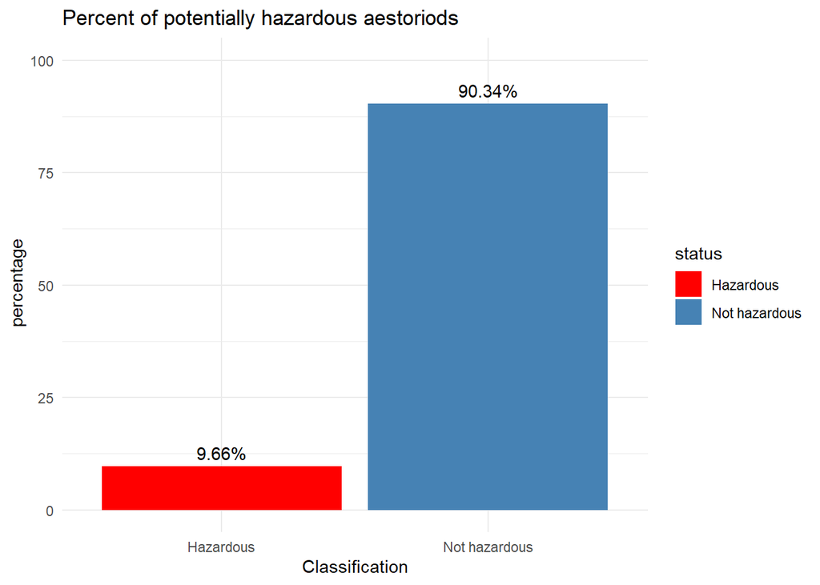

```r
#Graph for this
neo_dur_df %>%
  count(is_potentially_hazardous_asteroid) %>%
  mutate(
    percentage = 100 * n / sum(n),
    status = if_else(is_potentially_hazardous_asteroid, "Hazardous", "Not hazardous")
    ) %>%
  ggplot(aes(x = status, y = percentage, fill = status)) +
  geom_col() +
  geom_text(aes(label = paste0(round(percentage, 2), "%")),
            vjust = -0.5) +
  scale_fill_manual(values = c(
    "Hazardous" = "red",
    "Not hazardous" = "steelblue"
  )) +
  labs(
    title = "Percent of potentially hazardous aestoriods",
    x = "Classification",
    y = " percentage" ) +
  ylim(0, 100) +
  theme_minimal()
```

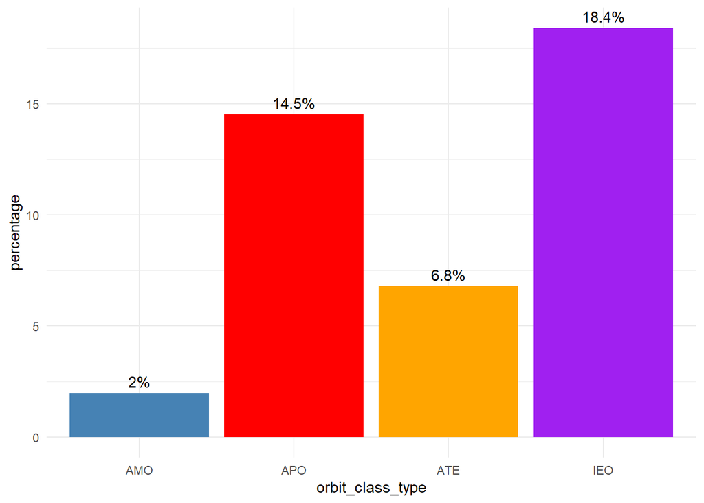

```r
#Consider how this relates to orbit type -
#APO — Apollo Earth-crossing asteroids whose semi-major axes are larger than Earth's. Their orbits extend farther from the Sun on average, but can cross Earth's orbital path.
#ATE — Aten Earth-crossing asteroids whose semi-major axes are smaller than Earth's. They orbit closer to the Sun on average and have orbital periods shorter than one year.
#AMO — Amor Asteroids that approach Earth's orbit from the outside but do not cross it. Their closest distance to the Sun is slightly beyond Earth's farthest distance from the Sun.
#IEO — Interior Earth Object (Atira) Asteroids with orbits entirely inside Earth's orbital path. Their maximum distance from the Sun is smaller than Earth's minimum distance from the Sun.

orbit_summary <- neo_dur_df %>%
  group_by(orbit_class_type) %>%
  summarise (
    total =n(),
    hazardous = sum(is_potentially_hazardous_asteroid),
    percentage = 100*hazardous / total
  )

ggplot(orbit_summary,
       aes(x=orbit_class_type, y=percentage, fill = orbit_class_type))+
  geom_col()+
  geom_text(aes(label = paste0(round(percentage, 1), "%")), vjust = -0.5)+
  scale_fill_manual(values =c(
    "AMO" = "steelblue",
    "APO" = "red",
    "ATE" = "orange",
    "IEO" = "purple"
  ))+
  theme_minimal() +
  theme(legend.position = "none")
```

Orbital Geometry Logistic Regression Model

```r
#set up training and testing data
set.seed(6767)
neo_testtraining <- initial_split(
  neo_dur_df,
  prop = 0.8,
  strata = is_potentially_hazardous_asteroid
)
neo_train <- training(neo_testtraining)
neo_test <- testing(neo_testtraining)

dim(neo_train)
```

```
## [1] 20695    44
```

```r
dim(neo_test)
```

```
## [1] 5174   44
```

```r
prop.table(table(neo_train$is_potentially_hazardous_asteroid))
```

```
##
##      FALSE       TRUE
## 0.90248852 0.09751148
```

```r
prop.table(table(neo_test$is_potentially_hazardous_asteroid))
```

```
##
##      FALSE       TRUE
## 0.90703518 0.09296482
```

```r
#Correlation between numerical orbit indicators

neo_train %>%
  select(
    eccentricity,
    inclination,
    semi_major_axis) %>%
  cor()
```

```
##                 eccentricity inclination semi_major_axis
## eccentricity      1.00000000 0.043788531     0.663092658
## inclination       0.04378853 1.000000000     0.001990392
## semi_major_axis   0.66309266 0.001990392     1.000000000
```

Eccentricity and semi-major axis show a relatively strong positively strong correlation, r = 0.663, this makes it difficult to understand their individual effects on classification of being a hazardous asteroid. Inclination shows negligible linear correlation with both eccentricity and the semi major axis (r=0.044, r=0.002). I will retain all three predictors as they describe distinct physical characteristics of the asteroids orbits.

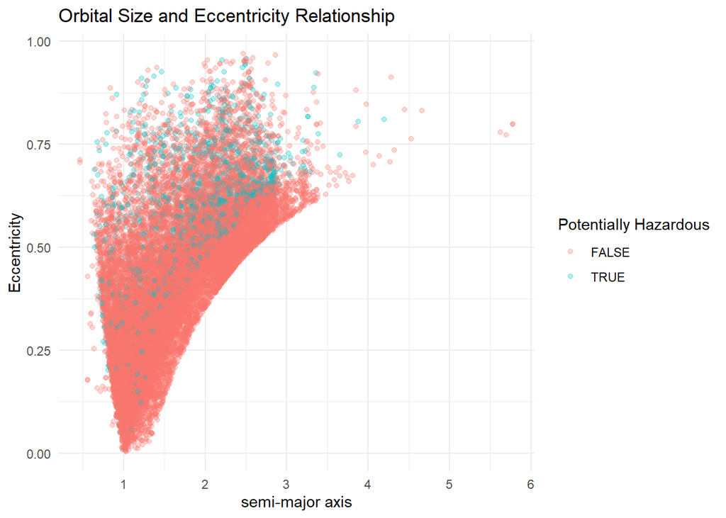

```r
#Visualise eccentricity and semi-major axis

ggplot(
  data = neo_train,
  aes(
    x= semi_major_axis,
    y = eccentricity,
    colour = is_potentially_hazardous_asteroid
  )
) +
  geom_point(alpha = 0.3) +
  labs(
    title = "Orbital Size and Eccentricity Relationship",
    x = "semi-major axis",
    y = "Eccentricity",
    colour = "Potentially Hazardous"
  )+
  theme_minimal()
```

The scatterplot supports the positive correlation between semi-major axis and eccentricity, although the relationship appears non-linear. There is substantial overlap between potentially hazardous and non-hazardous asteroids, suggesting that neither variable alone provides a clear distinction between the two classifications. This makes me want to construct a multiple logistic regression model incorporating additional orbital characteristics.

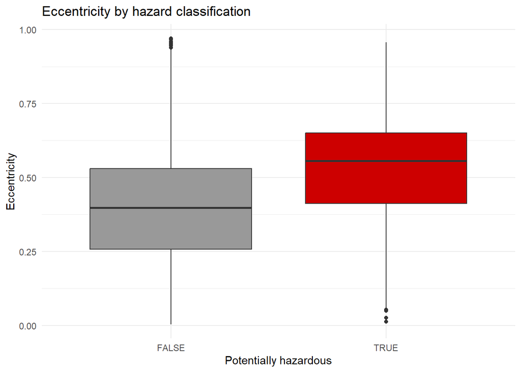

```r
# Eccentricity distribution by hazard classification

ggplot(
  data = neo_train,
  aes(
    x = as.factor(is_potentially_hazardous_asteroid),
    y = eccentricity,
    fill = as.factor(is_potentially_hazardous_asteroid)
  )
) +
  geom_boxplot() +
  scale_fill_manual(
    values = c("FALSE" = "grey60", "TRUE" = "red3")) +
  labs(
    title = "Eccentricity by hazard classification",
    x = "Potentially hazardous",
    y = "Eccentricity"
  ) +
  theme_minimal() +
  theme(legend.position = "none")
```

Potentially hazardous asteroids tend to have higher eccentricity with a median of approximately 0.55 compared to the non hazardous with 0.40. This suggests a positive association between eccentricity and hazard classification. However the overlapping interquartile ranges suggests that eccentricity alone is unlikely to allow us to reliably determine classification, suggesting we should include eccentricity alongside other orbital predictors in a multiple logistic regression model.

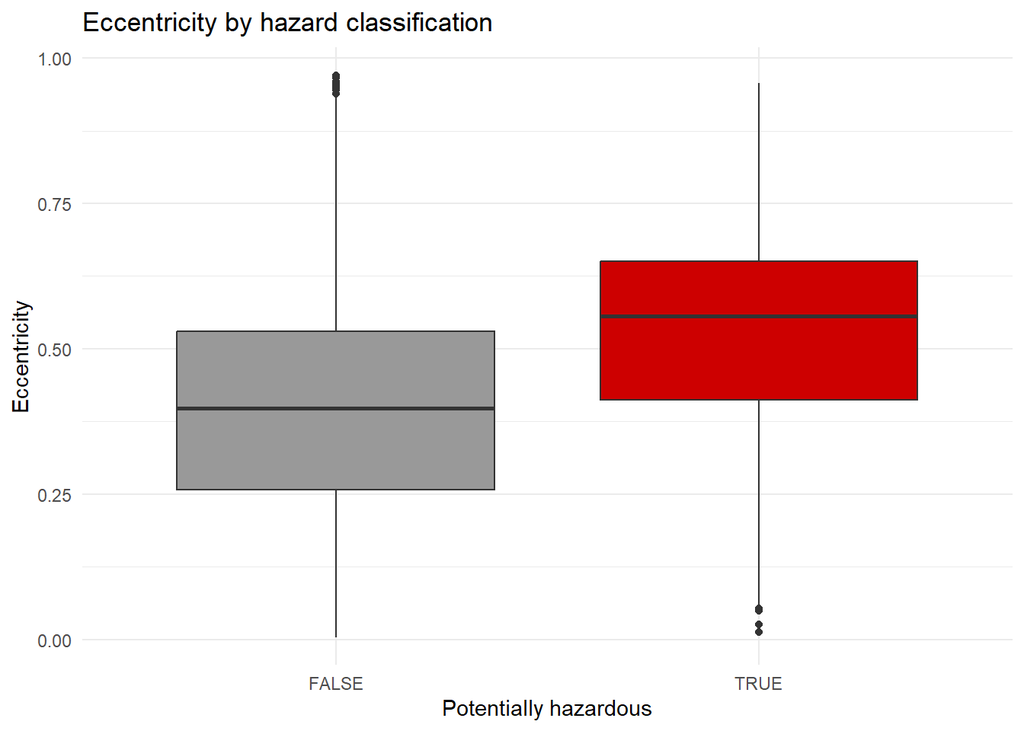

```r
# Eccentricity

ggplot(neo_train, aes(
  x = as.factor(is_potentially_hazardous_asteroid),
  y = eccentricity,
  fill = as.factor(is_potentially_hazardous_asteroid)
)) +
  geom_boxplot() +
  scale_fill_manual(
    values = c("FALSE" = "grey60", "TRUE" = "red3")
  ) +
  labs(
    title = "Eccentricity by hazard classification",
    x = "Potentially hazardous",
    y = "Eccentricity"
  ) +
  theme_minimal() +
  theme(legend.position = "none")
```

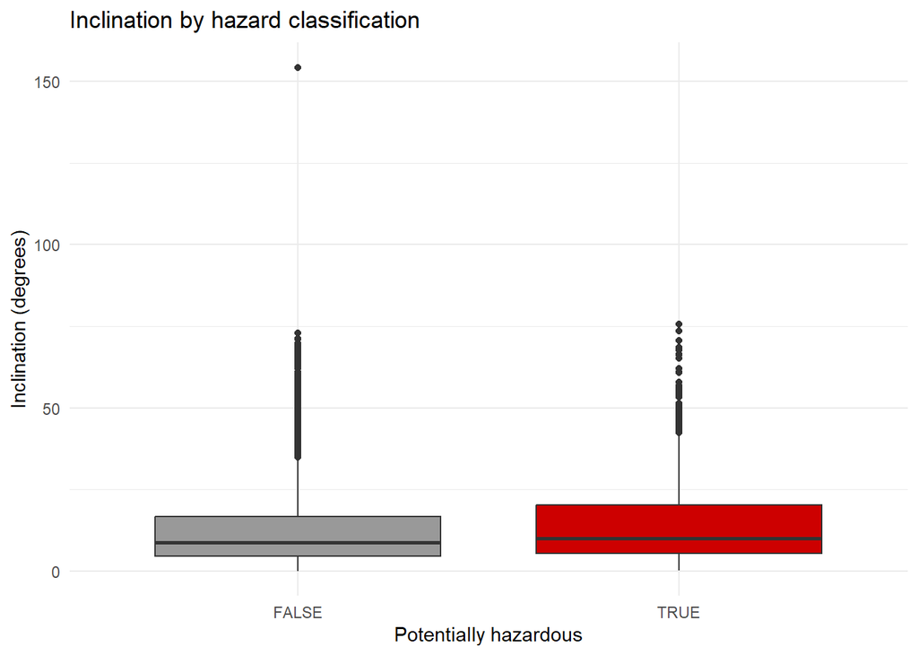

```r
# Inclination

ggplot(neo_train, aes(
  x = as.factor(is_potentially_hazardous_asteroid),
  y = inclination,
  fill = as.factor(is_potentially_hazardous_asteroid)
)) +
  geom_boxplot() +
  scale_fill_manual(
    values = c("FALSE" = "grey60", "TRUE" = "red3")
  ) +
  labs(
    title = "Inclination by hazard classification",
    x = "Potentially hazardous",
    y = "Inclination (degrees)"
  ) +
  theme_minimal() +
  theme(legend.position = "none")
```

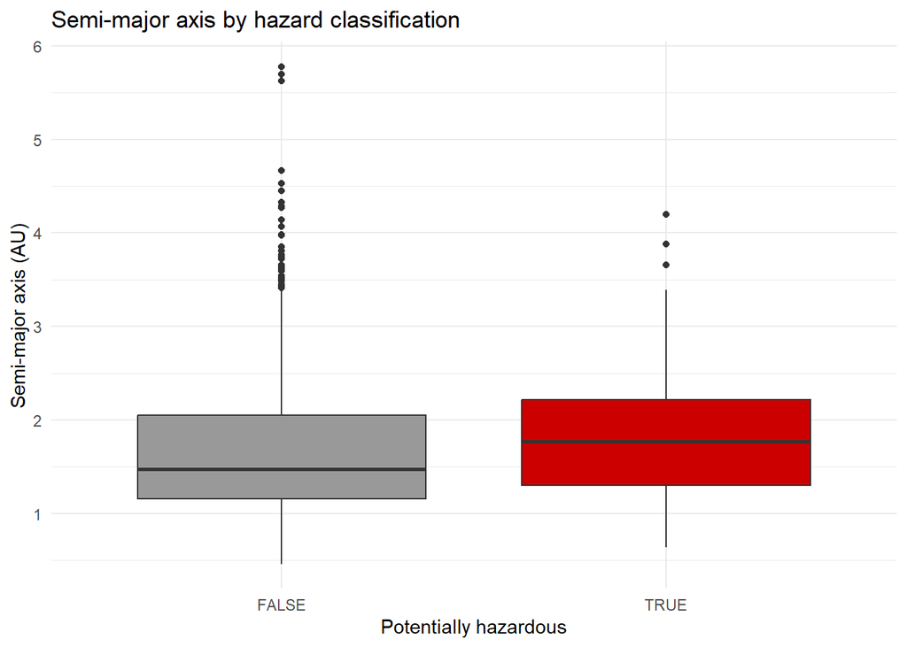

```r
# Semi-major axis

ggplot(neo_train, aes(
  x = as.factor(is_potentially_hazardous_asteroid),
  y = semi_major_axis,
  fill = as.factor(is_potentially_hazardous_asteroid)
)) +
  geom_boxplot() +
  scale_fill_manual(
    values = c("FALSE" = "grey60", "TRUE" = "red3")
  ) +
  labs(
    title = "Semi-major axis by hazard classification",
    x = "Potentially hazardous",
    y = "Semi-major axis (AU)"
  ) +
  theme_minimal() +
  theme(legend.position = "none")
```

Potentially hazardous asteroids generally exhibit higher eccentricity and larger semi-major axes, with median values of approximately 0.55 and 1.77 AU, compared to 0.40 and 1.47 AU for non-hazardous asteroids. Inclination demonstrates a considerably smaller difference between the two classifications, suggesting it may be a weaker individual predictor. However, all three variables exhibit overlapping distributions, suggesting that no single characteristic clearly distinguishes between the classifications. This motivates the construction of a multiple logistic regression model combining these characteristics with orbital class.

```r
#Multiple logistics regression model, Orbital characteristics

orbitalRM <- glm(
  is_potentially_hazardous_asteroid ~
    orbit_class_type +
    eccentricity+
    inclination+
    semi_major_axis,
  data = neo_train,
  family = binomial
)
summary(orbitalRM)
```

```
##
## Call:
## glm(formula = is_potentially_hazardous_asteroid ~ orbit_class_type +
##     eccentricity + inclination + semi_major_axis, family = binomial,
##     data = neo_train)
##
## Coefficients:
##                      Estimate Std. Error z value Pr(>|z|)
## (Intercept)         -6.018068   0.145815 -41.272  < 2e-16 ***
## orbit_class_typeAPO  2.150924   0.102317  21.022  < 2e-16 ***
## orbit_class_typeATE  2.012966   0.143913  13.987  < 2e-16 ***
## orbit_class_typeIEO  2.794089   0.511314   5.465 4.64e-08 ***
## eccentricity         2.656006   0.185711  14.302  < 2e-16 ***
## inclination          0.015678   0.002072   7.565 3.87e-14 ***
## semi_major_axis      0.356107   0.065044   5.475 4.38e-08 ***
## ---
## Signif. codes:  0 '***' 0.001 '**' 0.01 '*' 0.05 '.' 0.1 ' ' 1
##
## (Dispersion parameter for binomial family taken to be 1)
##
##     Null deviance: 13227  on 20694  degrees of freedom
## Residual deviance: 11522  on 20688  degrees of freedom
## AIC: 11536
##
## Number of Fisher Scoring iterations: 6
```

A multiple logistic regression model was fitted using orbital class, eccentricity, inclination and semi-major axis as explanatory variables. All coefficients were statistically significant at the 5% significance level. Eccentricity, inclination and semi-major axis showed positive associations with the odds of being hazardous when accounting for the other predictors. Apollo, Aten and Atira asteroids also exhibited higher estimated odds of hazard classification relative to Amor asteroids. The reduction in deviance from 13,227 to 11,522 indicates an improvement in model fit compared with the intercept-only model. However, predictive performance must be checked using the testing dataset.

```r
# Predict hazard probabilities using testing data

orbital_predictions <- neo_test %>%
  mutate( predicted_probability = predict(
      orbitalRM,
      newdata = neo_test,
      type = "response"
    )
  )

orbital_predictions %>%
  select(
    is_potentially_hazardous_asteroid,
    predicted_probability
  ) %>%
  head(10)
```

```
## # A tibble: 10 × 2
##    is_potentially_hazardous_asteroid predicted_probability
##    <lgl>                                             <dbl>
##  1 FALSE                                           0.00869
##  2 FALSE                                           0.238
##  3 FALSE                                           0.00908
##  4 TRUE                                            0.167
##  5 FALSE                                           0.0326
##  6 TRUE                                            0.0195
##  7 FALSE                                           0.0150
##  8 FALSE                                           0.268
##  9 FALSE                                           0.0167
## 10 TRUE                                            0.106
```

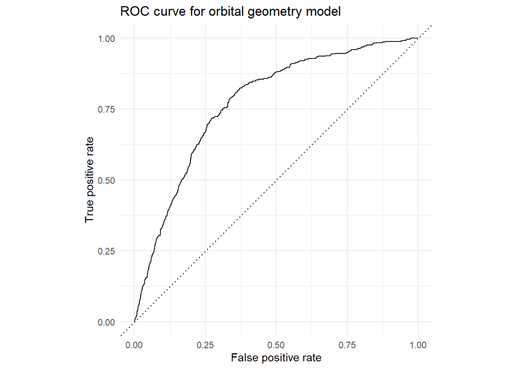

```r
#response variable to factor

orbital_predictions <- orbital_predictions %>%
  mutate(
    is_potentially_hazardous_asteroid = factor(
      is_potentially_hazardous_asteroid,
      levels = c(FALSE, TRUE)
    )
  )
#ROC curve
orbital_roc <- orbital_predictions %>%
  roc_curve(
    truth = is_potentially_hazardous_asteroid,
    predicted_probability,
    event_level = "second"
  )
autoplot(orbital_roc) +
  labs(
    title = "ROC curve for orbital geometry model",
    x = "False positive rate",
    y = "True positive rate"
  ) +
  theme_minimal()
```

```r
#AUC
orbital_auc <- orbital_predictions %>%
  roc_auc(
    truth = is_potentially_hazardous_asteroid,
    predicted_probability,
    event_level = "second"
  )
orbital_auc
```

```
## # A tibble: 1 × 3
##   .metric .estimator .estimate
##   <chr>   <chr>          <dbl>
## 1 roc_auc binary         0.772
```

The orbital geometry model achieved an AUC of 0.772 on the testing dataset, providing acceptable discriminatory ability. The ROC curve lies above the diagonal reference line, indicating that the model performs better than random guessing. This suggests that orbital geometry provides useful predictive information even when the defining criteria for hazard classification are excluded. However, the model remains imperfect, with a trade-off between correctly identifying potentially hazardous asteroids and incorrectly classifying non-hazardous asteroids as hazardous.

```r
# Classify asteroids using a threshold of 0.5

orbital_predictions <- orbital_predictions %>%
  mutate(
    predicted_class = factor(
      predicted_probability >= 0.5,
      levels = c(FALSE, TRUE)
    )
  )

#confusion matrix

orbital_predictions %>%
  conf_mat(
    truth = is_potentially_hazardous_asteroid,
    estimate = predicted_class
  )
```

```
##           Truth
## Prediction FALSE TRUE
##      FALSE  4686  478
##      TRUE      7    3
```

At a classification threshold of 0.5, the orbital geometry model achieved an overall accuracy of 90.63%. However, only 3 of the 481 potentially hazardous asteroids were correctly detected, resulting in a sensitivity of 0.62%. The high accuracy is misleading due to the imbalance between hazardous and non-hazardous observations. Given the importance of correctly identifying potentially hazardous asteroids, alternative classification thresholds should be investigated to improve sensitivity.

```r
#threshold of 0.1
orbital_predictions <- orbital_predictions %>%
  mutate(
    predicted_class_01 = factor(
      predicted_probability >= 0.1,
      levels = c(FALSE, TRUE)
    )
  )

orbital_predictions %>%
  conf_mat(
    truth = is_potentially_hazardous_asteroid,
    estimate = predicted_class_01
  )
```

```
##           Truth
## Prediction FALSE TRUE
##      FALSE  3207  119
##      TRUE   1486  362
```

Reducing the threshold from 0.5 to 0.1 increased sensitivity from 0.62% to 75.26%, reducing the number of false negatives from 478 to 119. However, overall accuracy decreased from 90.63% to 68.98%, and the number of false positives increased from 7 to 1,486. This clearly shows the trade-off between sensitivity and specificity. In the context of asteroid monitoring, a lower threshold may be preferable because failing to classify a potentially hazardous asteroid could be more dangerous than incorrectly identifying a non-hazardous asteroid.

```r
#threshold of 0.15

orbital_predictions <- orbital_predictions %>%
  mutate(
    predicted_class_015 = factor(
      predicted_probability >= 0.15,
      levels = c(FALSE, TRUE)
    )
  )

orbital_predictions %>%
  conf_mat(
    truth = is_potentially_hazardous_asteroid,
    estimate = predicted_class_015
  )
```

```
##           Truth
## Prediction FALSE TRUE
##      FALSE  3797  218
##      TRUE    896  263
```

```r
threshold_summary <- orbital_predictions %>%
  select(
    is_potentially_hazardous_asteroid,
    predicted_class,
    predicted_class_015,
    predicted_class_01
  ) %>%
  pivot_longer(
    cols = -is_potentially_hazardous_asteroid,
    names_to = "threshold",
    values_to = "prediction"
  ) %>%
  group_by(threshold) %>%
  summarise(
    accuracy = accuracy_vec(
      is_potentially_hazardous_asteroid, prediction
    ),
    sensitivity = sens_vec(
      is_potentially_hazardous_asteroid, prediction,
      event_level = "second"
    ),
    specificity = spec_vec(
      is_potentially_hazardous_asteroid, prediction,
      event_level = "second"
    )
  )

threshold_summary
```

```
## # A tibble: 3 × 4
##   threshold           accuracy sensitivity specificity
##   <chr>                  <dbl>       <dbl>       <dbl>
## 1 predicted_class        0.906     0.00624       0.999
## 2 predicted_class_01     0.690     0.753         0.683
## 3 predicted_class_015    0.785     0.547         0.809
```

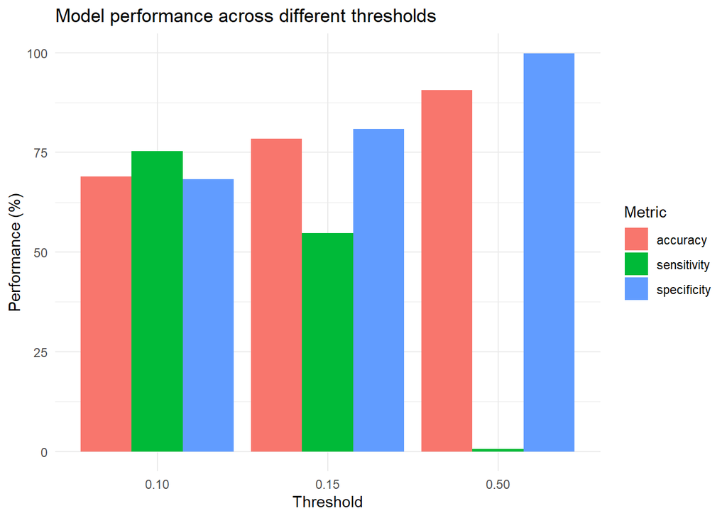

```r
threshold_summary %>%
  mutate(
    threshold = recode(
      threshold,
      "predicted_class" = "0.50",
      "predicted_class_015" = "0.15",
      "predicted_class_01" = "0.10"
    )
  ) %>%
  pivot_longer(
    cols = c(accuracy, sensitivity, specificity),
    names_to = "metric",
    values_to = "performance"
  ) %>%
  ggplot(aes(
    x = threshold,
    y = performance * 100,
    fill = metric
  )) +
  geom_col(position = "dodge") +
  labs(
    title = "Model performance across different thresholds",
    x = "Threshold",
    y = "Performance (%)",
    fill = "Metric"
  ) +
  theme_minimal()
```

The graph demonstrates that increasing the threshold improves overall accuracy and specificity but substantially reduces sensitivity. A threshold of 0.1 provides a more balanced classification performance, achieving a sensitivity of 75.26% and specificity of 68.34%. Although a threshold of 0.5 achieves the highest accuracy of the three thresholds investigated, it fails to identify almost all potentially hazardous asteroids. This highlights the limitations of using accuracy alone when evaluating models fitted to imbalanced datasets.

```r
# Correlation analysis for expanded orbital model

neo_train %>%
  select(
    eccentricity,
    inclination,
    semi_major_axis,
    perihelion_distance,
    aphelion_distance,
    orbital_period,
    mean_motion,
    ascending_node_longitude,
    perihelion_argument,
    jupiter_tisserand_invariant
  ) %>%
  cor() %>%
  round(3)
```

```
##                             eccentricity inclination semi_major_axis
## eccentricity                       1.000       0.044           0.663
## inclination                        0.044       1.000           0.002
## semi_major_axis                    0.663       0.002           1.000
## perihelion_distance               -0.341      -0.055           0.421
## aphelion_distance                  0.785       0.014           0.980
## orbital_period                     0.658       0.007           0.995
## mean_motion                       -0.552       0.012          -0.894
## ascending_node_longitude          -0.027      -0.004          -0.013
## perihelion_argument               -0.020       0.020          -0.045
## jupiter_tisserand_invariant       -0.635      -0.046          -0.926
##                             perihelion_distance aphelion_distance
## eccentricity                             -0.341             0.785
## inclination                              -0.055             0.014
## semi_major_axis                           0.421             0.980
## perihelion_distance                       1.000             0.234
## aphelion_distance                         0.234             1.000
## orbital_period                            0.398             0.980
## mean_motion                              -0.506            -0.848
## ascending_node_longitude                  0.015            -0.018
## perihelion_argument                      -0.037            -0.041
## jupiter_tisserand_invariant              -0.430            -0.900
##                             orbital_period mean_motion ascending_node_longitude
## eccentricity                         0.658      -0.552                   -0.027
## inclination                          0.007       0.012                   -0.004
## semi_major_axis                      0.995      -0.894                   -0.013
## perihelion_distance                  0.398      -0.506                    0.015
## aphelion_distance                    0.980      -0.848                   -0.018
## orbital_period                       1.000      -0.852                   -0.012
## mean_motion                         -0.852       1.000                    0.013
## ascending_node_longitude            -0.012       0.013                    1.000
## perihelion_argument                 -0.043       0.050                   -0.013
## jupiter_tisserand_invariant         -0.890       0.991                    0.015
##                             perihelion_argument jupiter_tisserand_invariant
## eccentricity                             -0.020                      -0.635
## inclination                               0.020                      -0.046
## semi_major_axis                          -0.045                      -0.926
## perihelion_distance                      -0.037                      -0.430
## aphelion_distance                        -0.041                      -0.900
## orbital_period                           -0.043                      -0.890
## mean_motion                               0.050                       0.991
## ascending_node_longitude                 -0.013                       0.015
## perihelion_argument                       1.000                       0.049
## jupiter_tisserand_invariant               0.049                       1.000
```

The correlation matrix reveals strong relationships between some orbital characteristics. Semi-major axis seems to show particularly strong correlations with orbital period (r = 0.995), aphelion distance (r = 0.980) and the Jupiter Tisserand invariant (r = −0.926). Including all these variables could make it difficult to clearly visulise their individual contributions to hazard classification. Therefore, highly correlated and redundent predictors will be excluded from the initial expanded model. Perihelion distance is selected for further investigation due to its physical relevance to the asteroid’s proximity to the Sun.

```r
# Create validation data for model refinement

set.seed(6767)

orbital_validation_split <- initial_split(
  neo_train,
  prop = 0.8,
  strata = is_potentially_hazardous_asteroid
)

orbital_development <- training(orbital_validation_split)

orbital_validation <- testing(orbital_validation_split)

dim(orbital_development)
```

```
## [1] 16556    44
```

```r
dim(orbital_validation)
```

```
## [1] 4139   44
```

```r
#Orignal
orbital_v1 <- glm(
  is_potentially_hazardous_asteroid ~
    orbit_class_type +
    eccentricity +
    inclination +
    semi_major_axis,
  data = orbital_development,
  family = binomial
)

summary(orbital_v1)
```

```
##
## Call:
## glm(formula = is_potentially_hazardous_asteroid ~ orbit_class_type +
##     eccentricity + inclination + semi_major_axis, family = binomial,
##     data = orbital_development)
##
## Coefficients:
##                      Estimate Std. Error z value Pr(>|z|)
## (Intercept)         -6.063442   0.162845 -37.234  < 2e-16 ***
## orbit_class_typeAPO  2.131984   0.113642  18.760  < 2e-16 ***
## orbit_class_typeATE  2.078227   0.159462  13.033  < 2e-16 ***
## orbit_class_typeIEO  2.924438   0.521935   5.603 2.11e-08 ***
## eccentricity         2.596515   0.208467  12.455  < 2e-16 ***
## inclination          0.016148   0.002307   7.001 2.54e-12 ***
## semi_major_axis      0.400485   0.072897   5.494 3.93e-08 ***
## ---
## Signif. codes:  0 '***' 0.001 '**' 0.01 '*' 0.05 '.' 0.1 ' ' 1
##
## (Dispersion parameter for binomial family taken to be 1)
##
##     Null deviance: 10557.9  on 16555  degrees of freedom
## Residual deviance:  9211.1  on 16549  degrees of freedom
## AIC: 9225.1
##
## Number of Fisher Scoring iterations: 6
```

```r
#V2

orbital_v2 <- glm(
  is_potentially_hazardous_asteroid ~
    orbit_class_type +
    eccentricity +
    inclination +
    semi_major_axis +
    perihelion_distance,
  data = orbital_development,
  family = binomial
)

summary(orbital_v2)
```

```
##
## Call:
## glm(formula = is_potentially_hazardous_asteroid ~ orbit_class_type +
##     eccentricity + inclination + semi_major_axis + perihelion_distance,
##     family = binomial, data = orbital_development)
##
## Coefficients:
##                      Estimate Std. Error z value Pr(>|z|)
## (Intercept)         -7.989014   0.404672 -19.742  < 2e-16 ***
## orbit_class_typeAPO  2.372686   0.122357  19.391  < 2e-16 ***
## orbit_class_typeATE  2.560349   0.185347  13.814  < 2e-16 ***
## orbit_class_typeIEO  3.483220   0.541313   6.435 1.24e-10 ***
## eccentricity         5.090807   0.525496   9.688  < 2e-16 ***
## inclination          0.017532   0.002305   7.605 2.85e-14 ***
## semi_major_axis     -0.212088   0.139359  -1.522    0.128
## perihelion_distance  1.861426   0.356382   5.223 1.76e-07 ***
## ---
## Signif. codes:  0 '***' 0.001 '**' 0.01 '*' 0.05 '.' 0.1 ' ' 1
##
## (Dispersion parameter for binomial family taken to be 1)
##
##     Null deviance: 10557.9  on 16555  degrees of freedom
## Residual deviance:  9183.1  on 16548  degrees of freedom
## AIC: 9199.1
##
## Number of Fisher Scoring iterations: 6
```

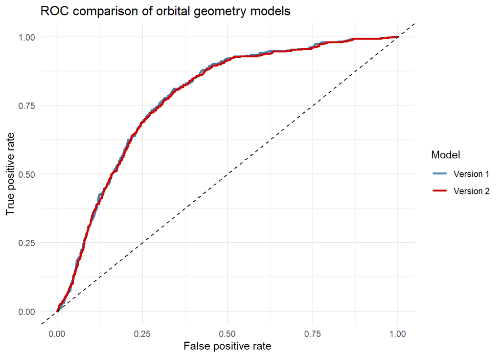

```r
orbital_comparison <- orbital_validation %>%
  mutate(
    is_potentially_hazardous_asteroid =
      factor(is_potentially_hazardous_asteroid,
             levels = c(FALSE, TRUE)),

    predicted_v1 = predict(
      orbital_v1,
      newdata = orbital_validation,
      type = "response"
    ),

    predicted_v2 = predict(
      orbital_v2,
      newdata = orbital_validation,
      type = "response"
    )
  )
#compare v1 and v2 ROC
orbital_comparison %>%
  pivot_longer(
    cols = c(predicted_v1, predicted_v2),
    names_to = "model",
    values_to = "probability"
  ) %>%
  group_by(model) %>%
  roc_curve(
    truth = is_potentially_hazardous_asteroid,
    probability,
    event_level = "second"
  ) %>%
  ggplot(aes(
    x = 1 - specificity,
    y = sensitivity,
    colour = model
  )) +
  geom_line(linewidth = 1) +
  geom_abline(linetype = "dashed") +
  scale_colour_manual(
    values = c("steelblue", "red3"),
    labels = c("Version 1", "Version 2")
  ) +
  labs(
    title = "ROC comparison of orbital geometry models",
    x = "False positive rate",
    y = "True positive rate",
    colour = "Model"
  ) +
  theme_minimal()
```

```r
# Compare validation AUC values

orbital_auc_comparison <- orbital_comparison %>%
  pivot_longer(
    cols = c(predicted_v1, predicted_v2),
    names_to = "model",
    values_to = "probability"
  ) %>%
  group_by(model) %>%
  roc_auc(
    truth = is_potentially_hazardous_asteroid,
    probability,
    event_level = "second"
  )

orbital_auc_comparison
```

```
## # A tibble: 2 × 4
##   model        .metric .estimator .estimate
##   <chr>        <chr>   <chr>          <dbl>
## 1 predicted_v1 roc_auc binary         0.782
## 2 predicted_v2 roc_auc binary         0.779
```

Despite reducing the AIC from 9,225.1 to 9,199.1, the addition of perihelion distance did not improve discriminatory ability on the dataset. The AUC actually decreased slightly from 0.782 to 0.779, with the ROC curves looking identitical. This may be explained by the mathematical relationship between perihelion distance, eccentricity and semi-major axis, limiting the additional predictive information provided. These findings show me that increasing model complexity and improving model fit do not necessarily improve predictive performance.

```r
# V3, removing semi-major axis

orbital_v3 <- glm(
  is_potentially_hazardous_asteroid ~
    orbit_class_type +
    eccentricity +
    inclination +
    perihelion_distance,
  data = orbital_development,
  family = binomial
)

summary(orbital_v3)
```

```
##
## Call:
## glm(formula = is_potentially_hazardous_asteroid ~ orbit_class_type +
##     eccentricity + inclination + perihelion_distance, family = binomial,
##     data = orbital_development)
##
## Coefficients:
##                      Estimate Std. Error z value Pr(>|z|)
## (Intercept)         -7.598346   0.311443 -24.397  < 2e-16 ***
## orbit_class_typeAPO  2.350392   0.121523  19.341  < 2e-16 ***
## orbit_class_typeATE  2.514642   0.182609  13.771  < 2e-16 ***
## orbit_class_typeIEO  3.432059   0.536731   6.394 1.61e-10 ***
## eccentricity         4.357370   0.207780  20.971  < 2e-16 ***
## inclination          0.017384   0.002308   7.533 4.98e-14 ***
## perihelion_distance  1.401472   0.188163   7.448 9.46e-14 ***
## ---
## Signif. codes:  0 '***' 0.001 '**' 0.01 '*' 0.05 '.' 0.1 ' ' 1
##
## (Dispersion parameter for binomial family taken to be 1)
##
##     Null deviance: 10557.9  on 16555  degrees of freedom
## Residual deviance:  9185.5  on 16549  degrees of freedom
## AIC: 9199.5
##
## Number of Fisher Scoring iterations: 6
```

Removing semi-major axis resulted in only a tiny increase in AIC from 9,199.1 to 9,199.5, whilst reducing the number of variables from five to four. All remaining predictor coefficients were statistically significant at the 5% significance level. This suggests that semi-major axis provides limited additional value when perihelion distance and eccentricity are included. However, validation performance must be assessed before selecting the final model.

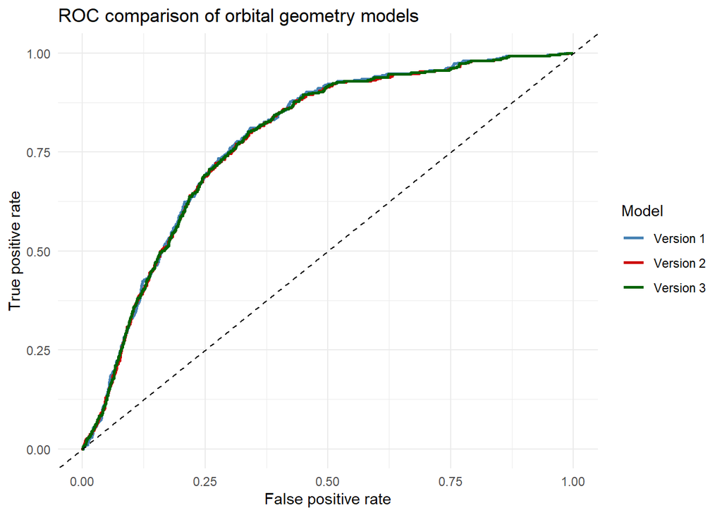

```r
# validation predictions

orbital_comparison <- orbital_comparison %>%
  mutate(
    predicted_v3 = predict(
      orbital_v3,
      newdata = orbital_validation,
      type = "response"
    )
  )

#ROC Compare 2
# Compare ROC curves for all three model versions

orbital_comparison %>%
  pivot_longer(
    cols = c(predicted_v1, predicted_v2, predicted_v3),
    names_to = "model",
    values_to = "probability"
  ) %>%
  group_by(model) %>%
  roc_curve(
    truth = is_potentially_hazardous_asteroid,
    probability,
    event_level = "second"
  ) %>%
  ggplot(aes(
    x = 1 - specificity,
    y = sensitivity,
    colour = model
  )) +
  geom_line(linewidth = 1) +
  geom_abline(linetype = "dashed") +
  scale_colour_manual(
    values = c("steelblue", "red3", "darkgreen"),
    labels = c("Version 1", "Version 2", "Version 3")
  ) +
  labs(
    title = "ROC comparison of orbital geometry models",
    x = "False positive rate",
    y = "True positive rate",
    colour = "Model"
  ) +
  theme_minimal()
```

```r
#AUC Vals
orbital_auc_comparison <- orbital_comparison %>%
  pivot_longer(
    cols = c(predicted_v1, predicted_v2, predicted_v3),
    names_to = "model",
    values_to = "probability"
  ) %>%
  group_by(model) %>%
  roc_auc(
    truth = is_potentially_hazardous_asteroid,
    probability,
    event_level = "second"
  )

orbital_auc_comparison
```

```
## # A tibble: 3 × 4
##   model        .metric .estimator .estimate
##   <chr>        <chr>   <chr>          <dbl>
## 1 predicted_v1 roc_auc binary         0.782
## 2 predicted_v2 roc_auc binary         0.779
## 3 predicted_v3 roc_auc binary         0.780
```

All three orbital geometry models demonstrated similar discriminatory ability, with validation AUC values of 0.782, 0.779 and 0.780 respectively. Despite Versions 2 and 3 achieving lower AIC values, neither demonstrated improved discriminatory ability compared with Version 1. This suggests that including perihelion distance provides limited additional predictive value. Version 1 was therefore retained as the final model due to its marginally higher validation AUC, relatively simple structure and interpretable explanatory variables.

Alfie’s Workspace

```r
#Making a new data set purely for orbiting body, velocity and miss distance
individual_observations <- neo_dur_df %>%
  pivot_longer(
    cols = matches("^(relative_velocity|orbiting_body|miss_distance_kilometers)[0-3]$"),
    names_to = c(".value", "observation"),
    names_pattern = "(relative_velocity|orbiting_body|miss_distance_kilometers)([0-3])"
  )
```

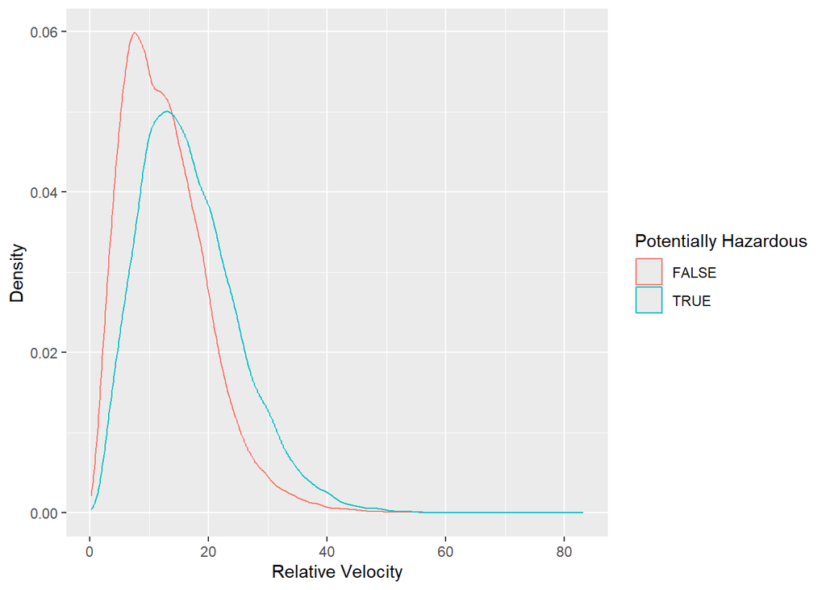

```r
#Displaying a density graph of relative velocities of NEOs

ggplot(
  data = individual_observations,
  mapping = aes(
    x = relative_velocity,
    colour = is_potentially_hazardous_asteroid)
  ) +
  geom_density() +
  labs(
    x = "Relative Velocity",
    y = "Density",
    colour = "Potentially Hazardous"
  )
```

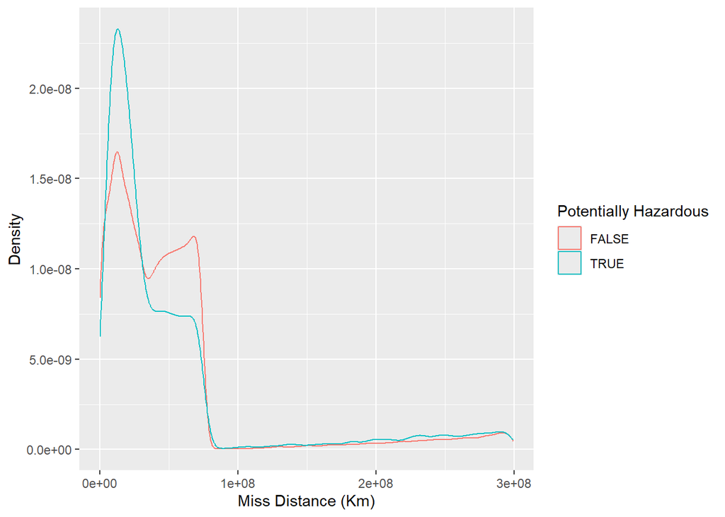

```r
#Displaying a density graph of miss distances for NEOs
individual_observations %>%
  ggplot(
  mapping = aes(
    x = miss_distance_kilometers,
    colour = is_potentially_hazardous_asteroid
  )
) +
  geom_density() +
  labs(
    x = "Miss Distance (Km)",
    y = "Density",
    colour = "Potentially Hazardous"
  )
```

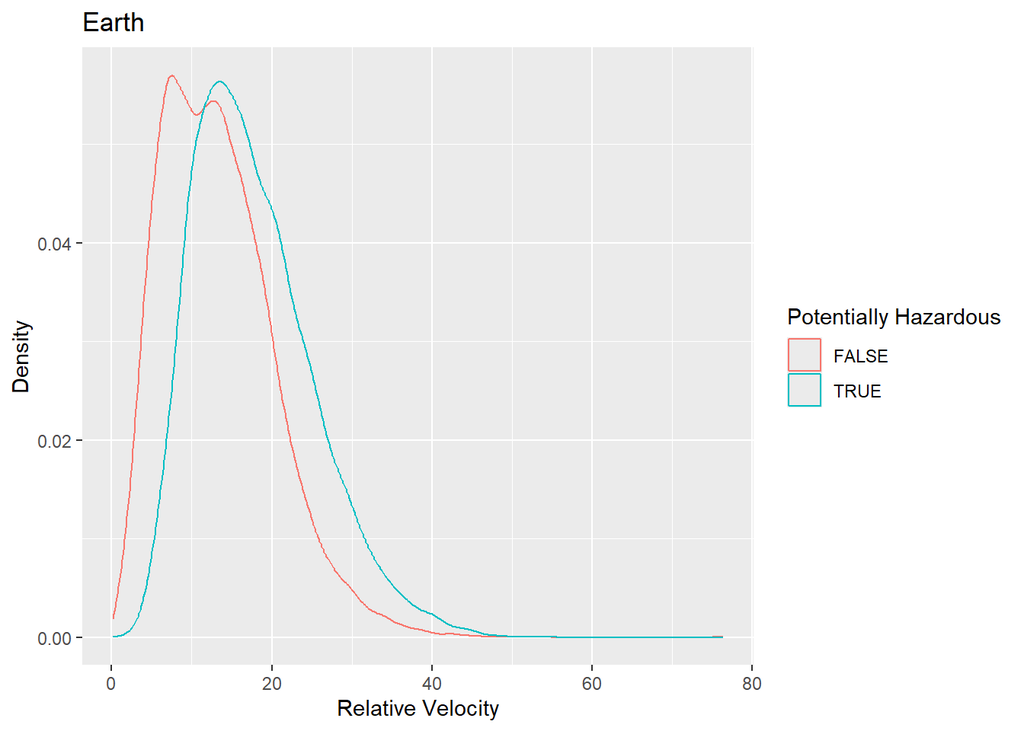

```r
individual_observations %>%
  filter(
    orbiting_body == "Earth"
  ) %>%
  ggplot(
  mapping = aes(
    x = relative_velocity,
    colour = is_potentially_hazardous_asteroid)
  ) +
  geom_density() +
  labs(
    title = "Earth",
    x = "Relative Velocity",
    y = "Density",
    colour = "Potentially Hazardous"
  )
```

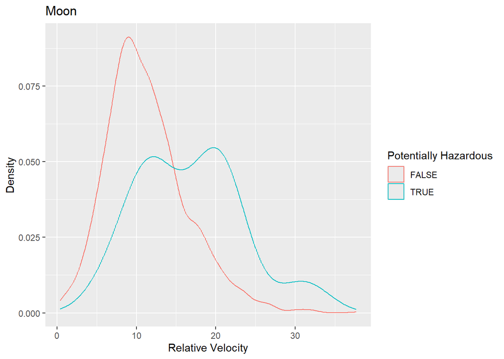

```r
individual_observations %>%
  filter(
    orbiting_body == "Moon"
  ) %>%
  ggplot(
  mapping = aes(
    x = relative_velocity,
    colour = is_potentially_hazardous_asteroid)
  ) +
  geom_density() +
  labs(
    title = "Moon",
    x = "Relative Velocity",
    y = "Density",
    colour = "Potentially Hazardous"
  )
```

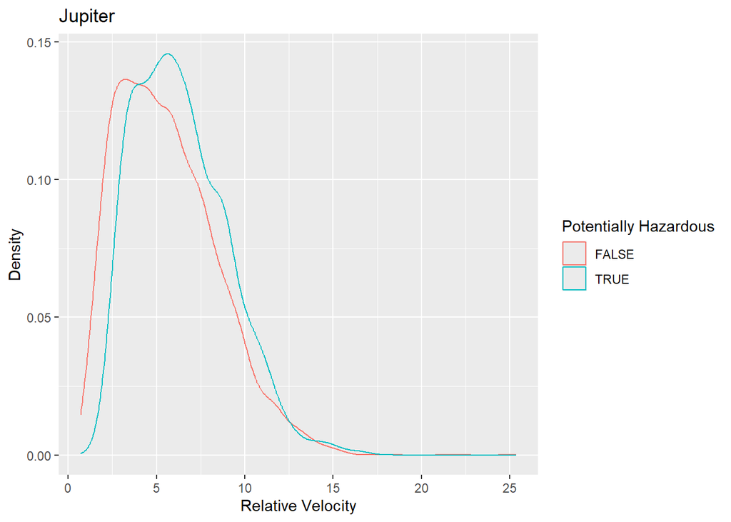

```r
individual_observations %>%
  filter(
    orbiting_body == "Juptr"
  ) %>%
  ggplot(
  mapping = aes(
    x = relative_velocity,
    colour = is_potentially_hazardous_asteroid)
  ) +
  geom_density() +
  labs(
    title = "Jupiter",
    x = "Relative Velocity",
    y = "Density",
    colour = "Potentially Hazardous"
  )
```

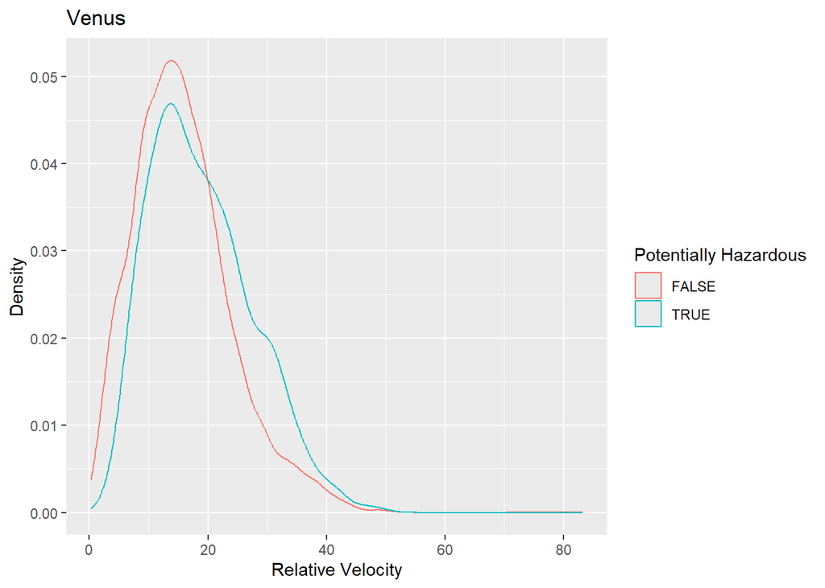

```r
individual_observations %>%
  filter(
    orbiting_body == "Venus"
  ) %>%
  ggplot(
  mapping = aes(
    x = relative_velocity,
    colour = is_potentially_hazardous_asteroid)
  ) +
  geom_density() +
  labs(
    title = "Venus",
    x = "Relative Velocity",
    y = "Density",
    colour = "Potentially Hazardous"
  )
```

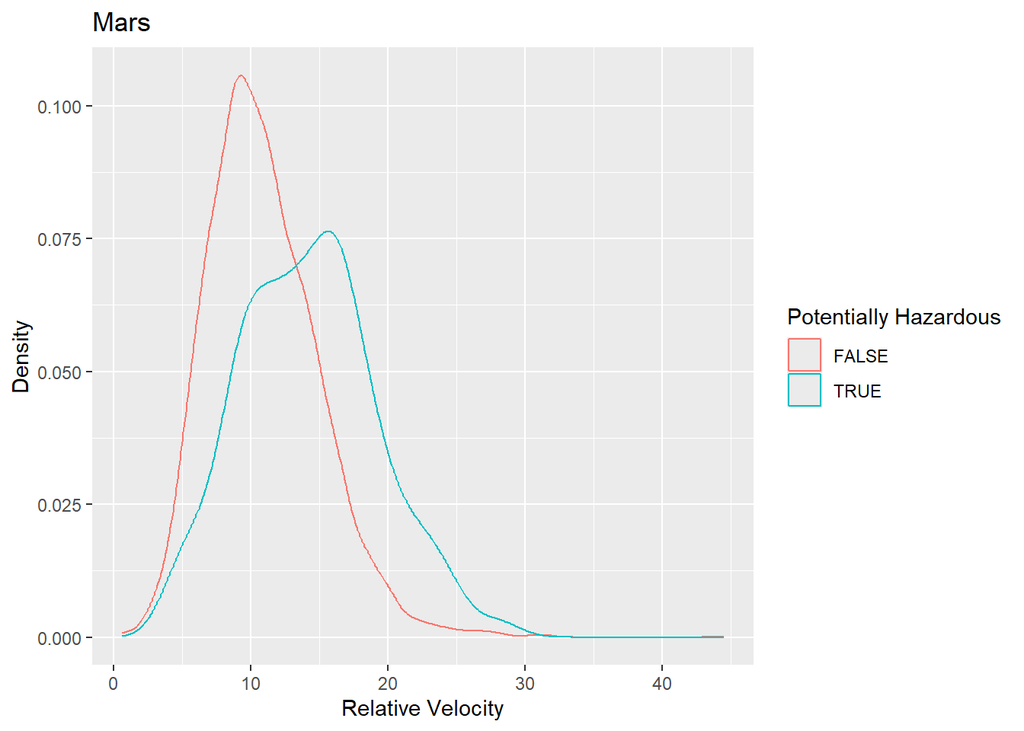

```r
individual_observations %>%
  filter(
    orbiting_body == "Mars"
  ) %>%
  ggplot(
  mapping = aes(
    x = relative_velocity,
    colour = is_potentially_hazardous_asteroid)
  ) +
  geom_density() +
  labs(
    title = "Mars",
    x = "Relative Velocity",
    y = "Density",
    colour = "Potentially Hazardous"
  )
```

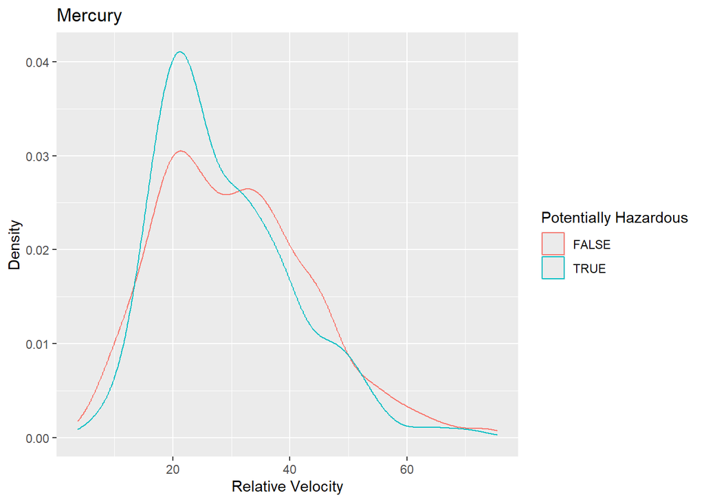

```r
individual_observations %>%
  filter(
    orbiting_body == "Merc"
  ) %>%
  ggplot(
  mapping = aes(
    x = relative_velocity,
    colour = is_potentially_hazardous_asteroid)
  ) +
  geom_density() +
  labs(
    title = "Mercury",
    x = "Relative Velocity",
    y = "Density",
    colour = "Potentially Hazardous"
  )
```

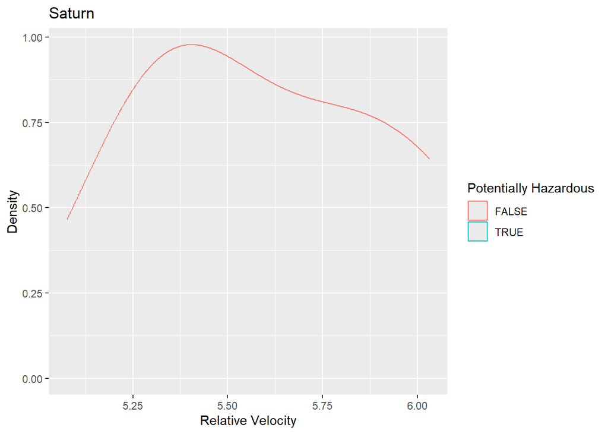

```r
individual_observations %>%
  filter(
    orbiting_body == "Satrn"
  ) %>%
  ggplot(
  mapping = aes(
    x = relative_velocity,
    colour = is_potentially_hazardous_asteroid)
  ) +
  geom_density() +
  labs(
    title = "Saturn",
    x = "Relative Velocity",
    y = "Density",
    colour = "Potentially Hazardous"
  )
```

```r
#Creating models to determine predictive power of variables
neo_dur_df <- neo_dur_df %>%
  mutate(is_potentially_hazardous_asteroid =
           as.factor(is_potentially_hazardous_asteroid))

set.seed(6767)
neo_split <- initial_split(neo_dur_df)
neo_train <- training(neo_split)
neo_test <- testing(neo_split)


neo_rec_1 <- recipe(
  is_potentially_hazardous_asteroid ~ relative_velocity0,
  data = neo_dur_df
)
neo_mod_1 <- logistic_reg() %>%
  set_engine("glm")

neo_wflow_1 <- workflow() %>%
  add_recipe(neo_rec_1) %>%
  add_model(neo_mod_1)

neo_fit_1 <- fit(neo_wflow_1, data = neo_train)
neo_predictions_1 <- augment(neo_fit_1, new_data = neo_test)
```

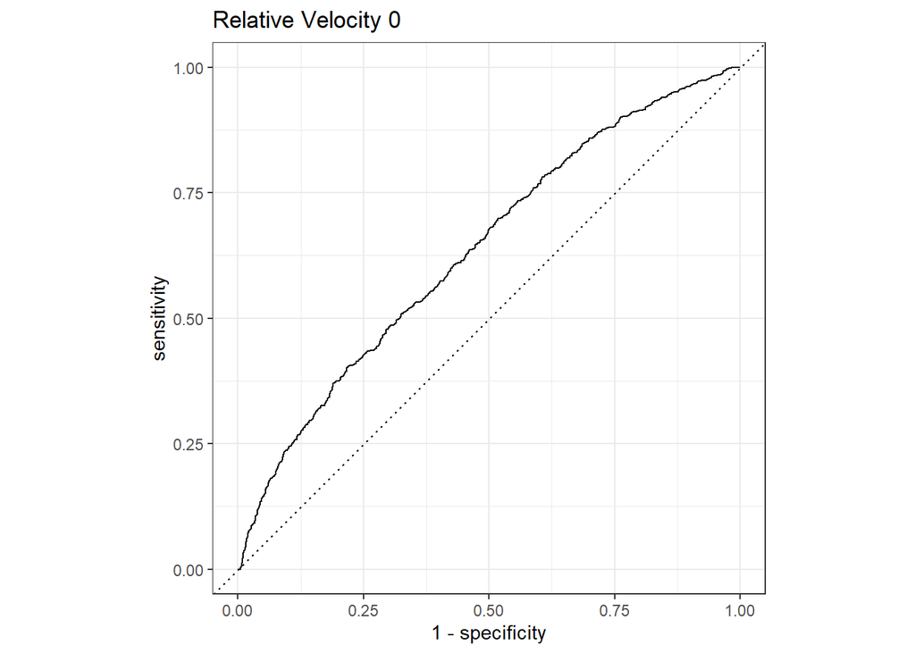

```r
neo_roc_1 <- roc_curve(
  neo_predictions_1,
  truth = is_potentially_hazardous_asteroid,
  .pred_TRUE,
  event_level = "second")

autoplot(neo_roc_1) +
  labs(
    title = "Relative Velocity 0"
  )
```

```r
neo_predictions_1 %>%
  roc_auc(
    truth = is_potentially_hazardous_asteroid,
    .pred_TRUE,
    event_level = "second"
  )
```

```
## # A tibble: 1 × 3
##   .metric .estimator .estimate
##   <chr>   <chr>          <dbl>
## 1 roc_auc binary         0.636
```

```r
#Logistic Model for Miss Distance 0 and Potential Hazard
neo_rec_2 <- recipe(
  is_potentially_hazardous_asteroid ~ miss_distance_kilometers0,
  data = neo_dur_df
)
neo_mod_2 <- logistic_reg() %>%
  set_engine("glm")

neo_wflow_2 <- workflow() %>%
  add_recipe(neo_rec_2) %>%
  add_model(neo_mod_2)

neo_fit_2 <- fit(neo_wflow_2, data = neo_train)
neo_predictions_2 <- augment(neo_fit_2, new_data = neo_test)
```

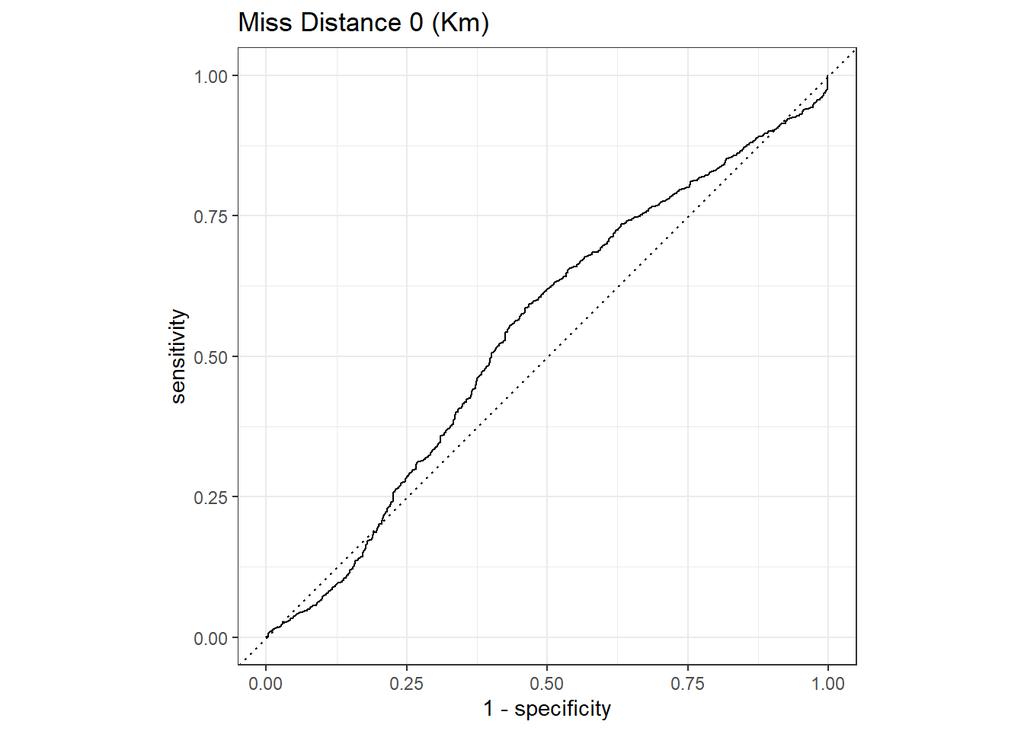

```r
neo_roc_2 <- roc_curve(
  neo_predictions_2,
  truth = is_potentially_hazardous_asteroid,
  .pred_TRUE,
  event_level = "first")

autoplot(neo_roc_2) +
  labs(
    title = "Miss Distance 0 (Km)"
  )
```

```r
neo_predictions_2 %>%
  roc_auc(
    truth = is_potentially_hazardous_asteroid,
    .pred_TRUE,
    event_level = "first"
  )
```

```
## # A tibble: 1 × 3
##   .metric .estimator .estimate
##   <chr>   <chr>          <dbl>
## 1 roc_auc binary         0.543
```

```r
#Logistic model for estimated diameter and potential hazard
neo_rec_3 <- recipe(
  is_potentially_hazardous_asteroid ~ estimated_diameter_kilometers_max,
  data = neo_dur_df
)
neo_mod_3 <- logistic_reg() %>%
  set_engine("glm")

neo_wflow_3 <- workflow() %>%
  add_recipe(neo_rec_3) %>%
  add_model(neo_mod_3)

neo_fit_3 <- fit(neo_wflow_3, data = neo_train)
neo_predictions_3 <- augment(neo_fit_3, new_data = neo_test)
```

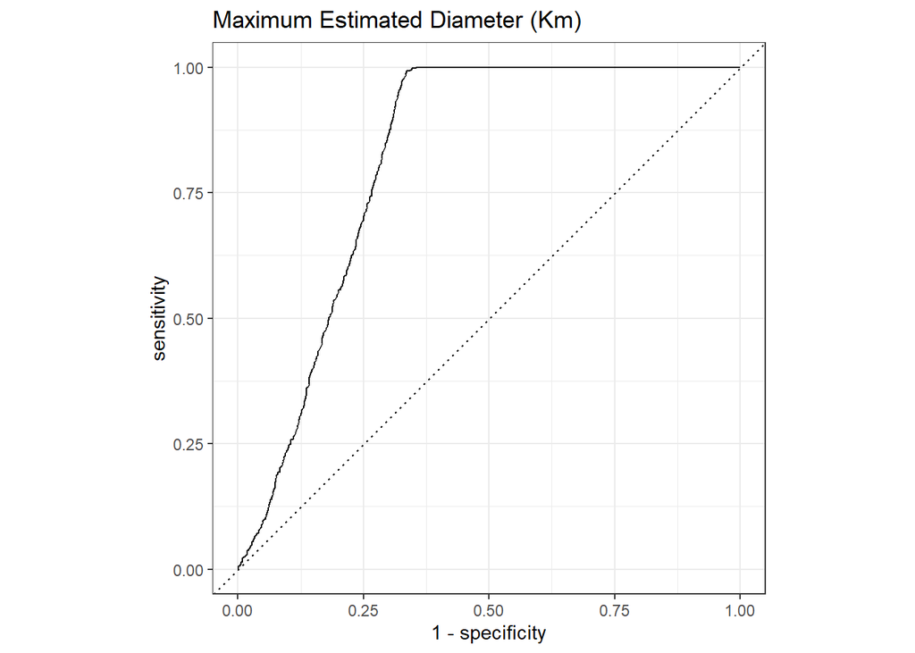

```r
neo_roc_3 <- roc_curve(
  neo_predictions_3,
  truth = is_potentially_hazardous_asteroid,
  .pred_TRUE,
  event_level = "second")

autoplot(neo_roc_3) +
  labs(
    title = "Maximum Estimated Diameter (Km)"
  )
```

```r
neo_predictions_3 %>%
  roc_auc(
    truth = is_potentially_hazardous_asteroid,
    .pred_TRUE,
    event_level = "second"
  )
```

```
## # A tibble: 1 × 3
##   .metric .estimator .estimate
##   <chr>   <chr>          <dbl>
## 1 roc_auc binary         0.818
```

```r
neo_rec_4 <- recipe(
  is_potentially_hazardous_asteroid ~ estimated_diameter_kilometers_max + relative_velocity0 + miss_distance_kilometers0,
  data = neo_dur_df
)
neo_mod_4 <- logistic_reg() %>%
  set_engine("glm")

neo_wflow_4 <- workflow() %>%
  add_recipe(neo_rec_4) %>%
  add_model(neo_mod_4)

neo_fit_4 <- fit(neo_wflow_4, data = neo_train)
neo_predictions_4 <- augment(neo_fit_4, new_data = neo_test)
```

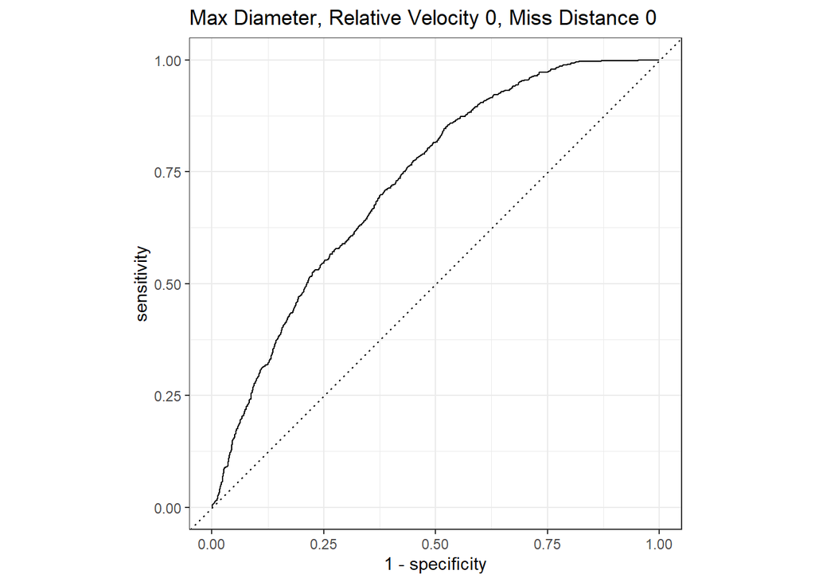

```r
neo_roc_4 <- roc_curve(
  neo_predictions_4,
  truth = is_potentially_hazardous_asteroid,
  .pred_TRUE,
  event_level = "second")

autoplot(neo_roc_4) +
  labs(
    title = "Max Diameter, Relative Velocity 0, Miss Distance 0"
  )
```

```r
neo_predictions_4 %>%
  roc_auc(
    truth = is_potentially_hazardous_asteroid,
    .pred_TRUE,
    event_level = "second"
  )
```

```
## # A tibble: 1 × 3
##   .metric .estimator .estimate
##   <chr>   <chr>          <dbl>
## 1 roc_auc binary         0.726
```

Jonah’s Workspace

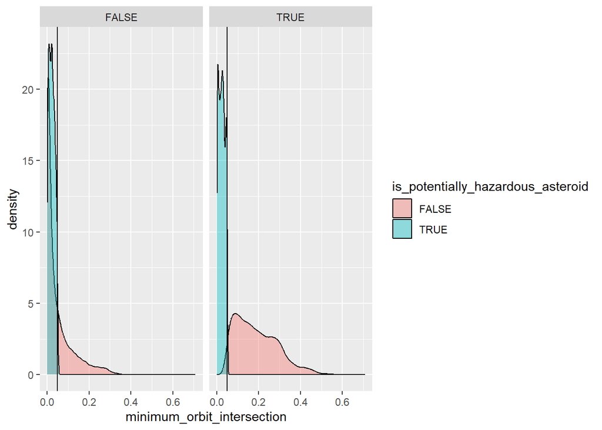

```r
### DATA VISUALISATIONS
neo_dur_df %>%
  mutate(
    is_large_enough = if_else(estimated_diameter_kilometers_min > 0.14, TRUE, FALSE)
  ) %>%
  ggplot() +
  geom_density(aes(minimum_orbit_intersection, fill = is_potentially_hazardous_asteroid), alpha = 0.4) +
  geom_vline(xintercept = 0.05) +
  facet_wrap(~is_large_enough)
```

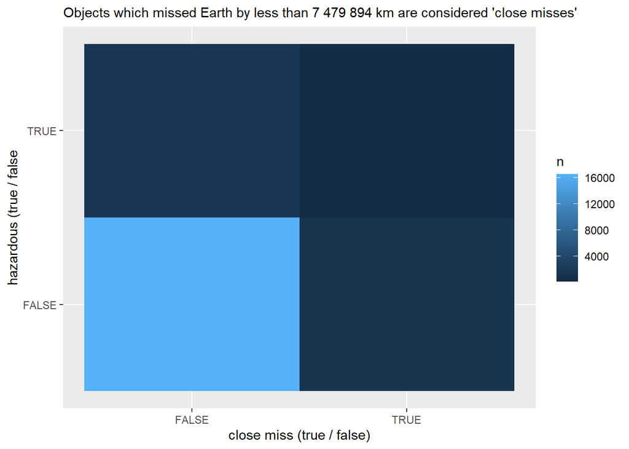

```r
# Classifying NEOs based on how close they got to Earth and then comparing this to whether they were deemed hazardous. Less than ~7.5M km is considered a close miss.
neo_dur_df %>%
  filter(orbiting_body0 == "Earth") %>%
  mutate(
    is_close_miss = case_when(
      miss_distance_kilometers0 < 7479894 ~TRUE,
      miss_distance_kilometers0 >= 7479894 ~FALSE
    )) %>%
  count(is_potentially_hazardous_asteroid, is_close_miss) %>%
  ggplot() +
  geom_tile(aes(is_close_miss, is_potentially_hazardous_asteroid, fill = n)) +
  labs(
    subtitle = "Objects which missed Earth by less than 7 479 894 km are considered 'close misses'",
    x = "close miss (true / false)",
    y = "hazardous (true / false"
      )
```

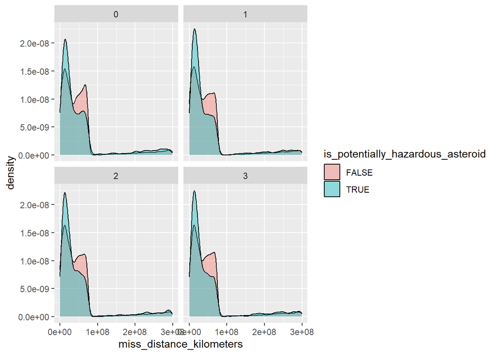

```r
# There is no "threshold" for miss_distance above which neos are not classified as hazardous
ggplot(individual_observations, aes(miss_distance_kilometers, fill = is_potentially_hazardous_asteroid)) +
  geom_density(alpha = 0.4) +
  facet_wrap(~ observation, scales = "fixed")
```

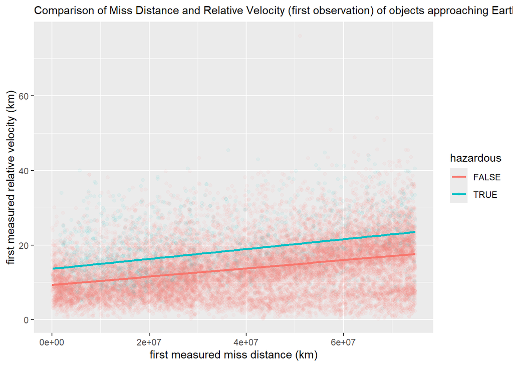

```r
# Investigating the relationship between miss distance, relative velocity and hazard assessment.
neo_dur_df %>%
  filter(orbiting_body0 == "Earth") %>%
  ggplot(aes(miss_distance_kilometers0, relative_velocity0, color = is_potentially_hazardous_asteroid)) +
  geom_point(alpha = 0.05) +
  geom_smooth(method = "lm", se = FALSE) +
  labs(
    subtitle = "Comparison of Miss Distance and Relative Velocity (first observation) of objects approaching Earth",
    x = "first measured miss distance (km)",
    y = "first measured relative velocity (km)",
    color = "hazardous"
  )
```

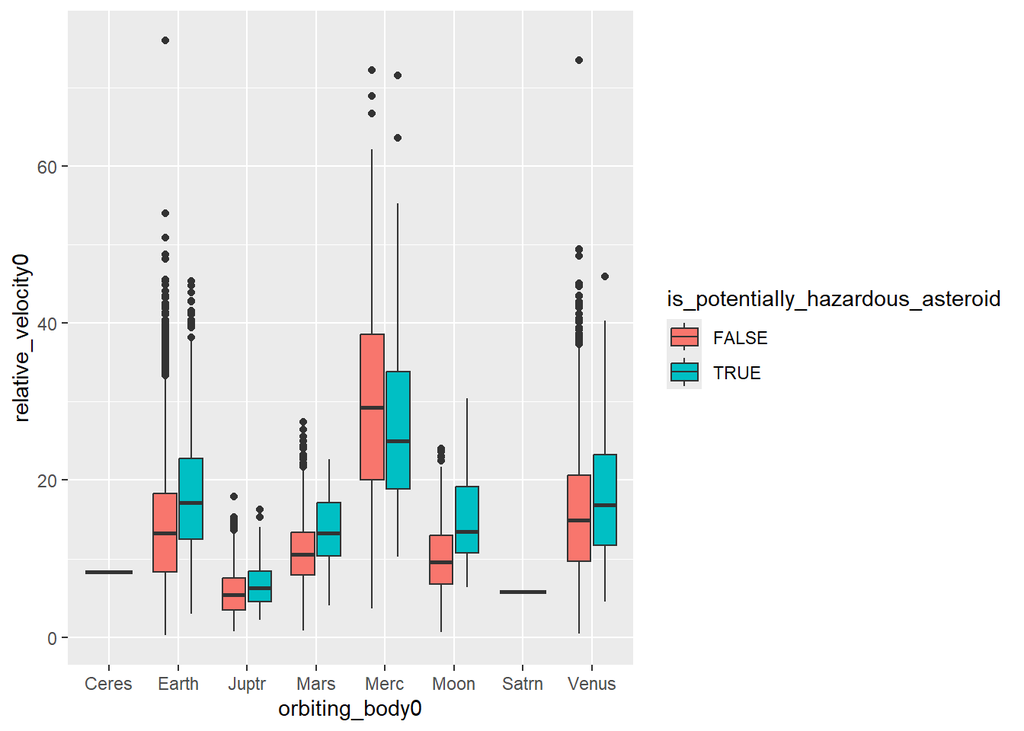

```r
# investigating the distribution of relative_velocity0 and miss_distance_kilometers0 per orbiting_body0
ggplot(neo_dur_df, aes(orbiting_body0, relative_velocity0, fill = is_potentially_hazardous_asteroid)) +
  geom_boxplot()
```

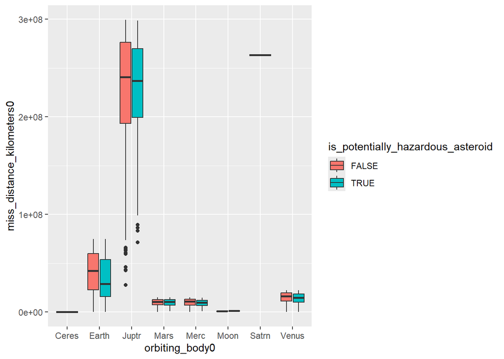

```r
ggplot(neo_dur_df, aes(orbiting_body0, miss_distance_kilometers0, fill = is_potentially_hazardous_asteroid)) +
  geom_boxplot()
```

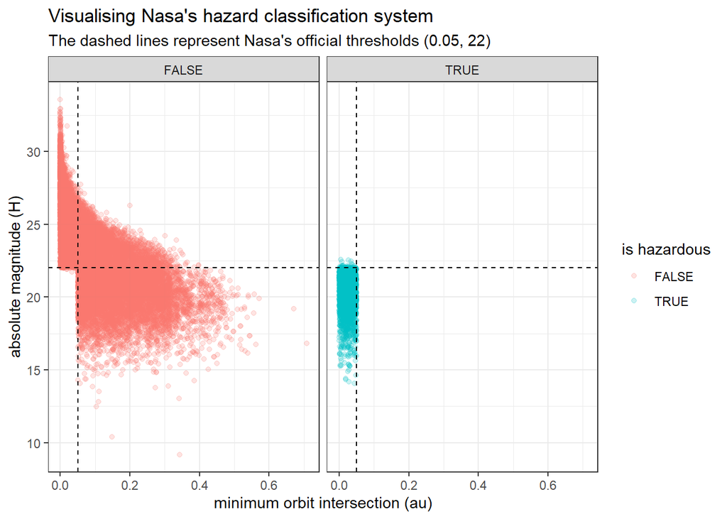

```r
minimum_orbit_intersection_threshold <- 0.05
absolute_magnitude_threshold <- 22
# taken from https://cneos.jpl.nasa.gov/about/neo_groups.html
ggplot(neo_dur_df, aes(minimum_orbit_intersection, absolute_magnitude_h, colour = is_potentially_hazardous_asteroid)) +
  geom_point(alpha = 0.2) +
  facet_wrap(~is_potentially_hazardous_asteroid) +
  geom_vline(xintercept = minimum_orbit_intersection_threshold, linetype = "dashed") +
  geom_hline(yintercept = absolute_magnitude_threshold, linetype = "dashed") +
  labs(
    x = "minimum orbit intersection (au)",
    y = "absolute magnitude (H)",
    title = "Visualising Nasa's hazard classification system",
    subtitle = "The dashed lines represent Nasa's official thresholds (0.05, 22)",
    color = "is hazardous"
  ) +
  theme_bw()
```